# Week 1 Tasks

## Task 1 - Literature

### 1. Read the research article of the hands-on working group you are assigned to:

*Spatial Transcriptional Mapping Reveals Site-Specific Pathways Underlying Human Atherosclerotic Plaque Rupture* https://www.jacc.org/doi/epdf/10.1016/j.jacc.2023.04.008

### 2. Answer the following questions

##### a. What is the medically relevant insight from the article?

*“plaque site–specific transcriptional signatures associated with proximal rupture-prone regions of carotid atherosclerotic plaques.”*

##### b. Which genomics technology/ technologies were used?

*Histology, SEM, bulk and spatial RNA-seq, GWAS*

### 3. Further related research questions

##### a. List and explain at least three questions/ hypotheses you can think of that extend the analysis presented in the paper.

- MMP9-Associated Pathway Analysis
- GWAS-Identified Variants Linked to MMP9
- Identification of Potential Therapeutic Targets Beyond MMP9 Based on Expression and Survival.

## Task 2 - Git repositories and R Markdown

## Task 3 - Introduction to R and online R course

## Task 4 - Using R example datasets

### 1. Use the R internal CO2 dataset (“data(CO2)”).

```r
library(tidyverse)
data(CO2)
```

### 2. Describe briefly the content of the CO2 dataset using the help function.

```r
help(CO2)
```

### 3. What is the average and median CO2 uptake of the plants from Quebec and Mississippi?

```r
Quebec = CO2 %>% filter(Type == "Quebec")
Mississippi = CO2 %>% filter(Type == "Mississippi")

#average and median CO2 uptake from Quebec:
mean(Quebec$uptake)
```

```
## [1] 33.54286
```

```r
median(Quebec$uptake)
```

```
## [1] 37.15
```

```r
#average and median CO2 uptake from Mississippi:
mean(Mississippi$uptake)
```

```
## [1] 20.88333
```

```r
median(Mississippi$uptake)
```

```
## [1] 19.3
```

## Task 5 - R Functions

### 1. Write a function that calculates the ratio of the mean and the median of a given vector. 5 This is a helpful measure to detect data with outlying values. Note: See Reference for R language

```r
ratio.cal = function(x){
  ratio = mean(x)/median(x)
  return(ratio)
}
```

### 2. Write a function that ignores the lowest and the highest value from a given vector and calculate the mean.

```r
mean.fil = function(x){
  x = x[ x != max(x) & x != min(x)]
  mean.fil = mean(x)
  return(mean.fil)
}
```

### 3. Read about piping from here:https://r4ds.had.co.nz/pipes.html#pipes (you don’t have to learn everything, a basic understanding of the usage is enough). Write a short (max. 300 characters, no spaces) explanation of why, how, and when not to use pipes.

*Pipes in R, represented by the %>% operator, streamline code readability and improve workflow. They facilitate a more intuitive left-to-right flow, making it easier to understand how data is being transformed.*

*The basic structure involves chaining functions or operations in a sequential manner using %>%. The output of one function becomes the input for the next.*

*When not to use the pip: longer than ten stips, have multiple inputs or outputs and if you want a directed graph.*

### 4. Familiarize yourself with the apply-family of functions (apply, lapply, sapply etc.) http://uc-r.github.io/apply_family Write a short explanation (max. 300 characters, no spaces) of why they could be useful in your work.

*The apply-family functions are powerful tools for applying a specified function to elements of an array, list, or data frame. They significantly streamline and optimize data processing, particularly when dealing with large datasets or complex data structures.*

*They are more efficient and simplify the code. Ease to use with consistency and reproducibility.*

## Task 6 - Basic visualization with R

### 1. Compare the distributions of the body heights of the two species from the ‘magic_guys.csv’ dataset graphically

```r
library(ggplot2)
magic = read.csv("~/Downloads/Week_1/magic_guys.csv")
```

##### a. using the basic ‘hist’ function as well as ‘ggplot’ and ‘geom_histogram’ functions from the ggplot2 package. Optimize the plots for example by trying several different ‘breaks’. Note that ggplot2-based functions give you many more options for changing the visualization parameters, try some of them.

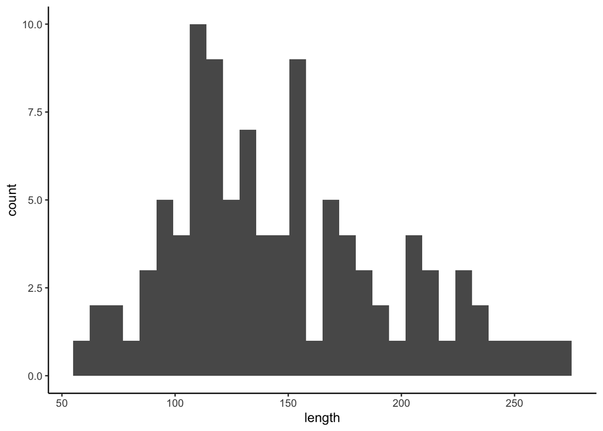

```r
ggplot(magic, aes(x=length))+geom_histogram()+xlab("length") + theme_classic()
```

##### b. Do the same comparison as in a. but with boxplots. If you want to use the ggplot2-package, use the functions ‘ggplot’ and ‘geom_boxplot’.

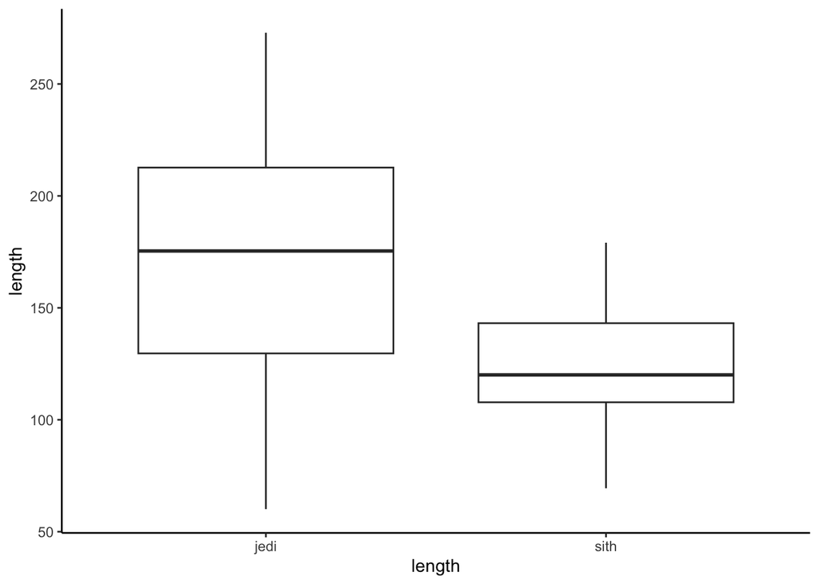

```r
ggplot(magic, aes(y=length, x=species))+geom_boxplot()+xlab("length") + theme_classic()
```

##### c. Save the plots with the ‘png’, ‘pdf’, and ‘svg’ formats. In which situation would you use which file format?

```r
#ggsave("hist", plt1, device = "pdf")
```

### 2. Load the gene expression data matrix from the ‘microarray_data.tab’ dataset provided in the shared folder, it is a big tabular separated matrix.

```r
micro = read.table("~/Downloads/Week_1/microarray_data.tab", sep = "\t", header = T)
```

### a. How big is the matrix in terms of rows and columns?

```r
dim(micro)
```

```
## [1]  553 1000
```

### b. Count the missing values per gene and visualize this result.

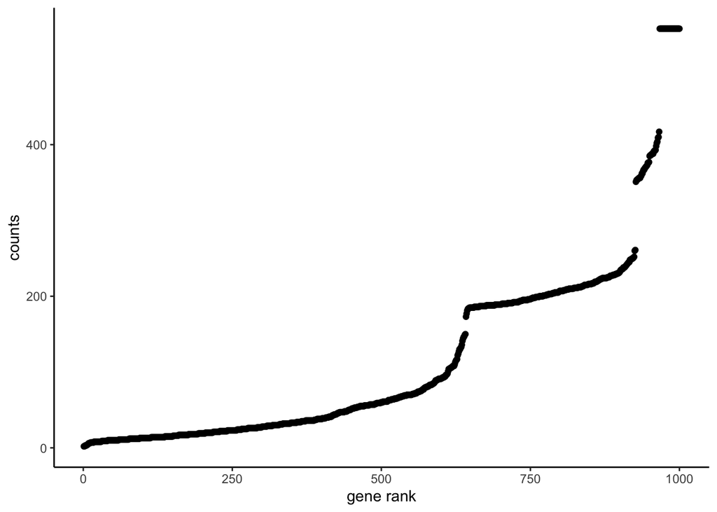

```r
library(dplyr)
n.genes = ncol(micro)
counts.na = sapply(micro, function(x) sum(is.na(x))) %>% as.data.frame() %>%
  rename(counts = ".") %>% arrange(counts) %>% mutate(number = 1:n.genes)
ggplot(counts.na, aes(x = number, y=counts))+geom_point()+xlab("gene rank") + theme_classic()
```

### c. Find the genes for which there are more than X% (X=10%, 20%, 50%) missing values.

```r
genes.10pct = counts.na %>% filter(counts > (n.genes * 0.1)) %>% rownames()
genes.20pct = counts.na %>% filter(counts > (n.genes * 0.2)) %>% rownames()
genes.50pct = counts.na %>% filter(counts > (n.genes * 0.5)) %>% rownames()
```

###3. Visualize the data in the CO2 dataset in a way that gives you a deeper understanding of the data. What do you see?

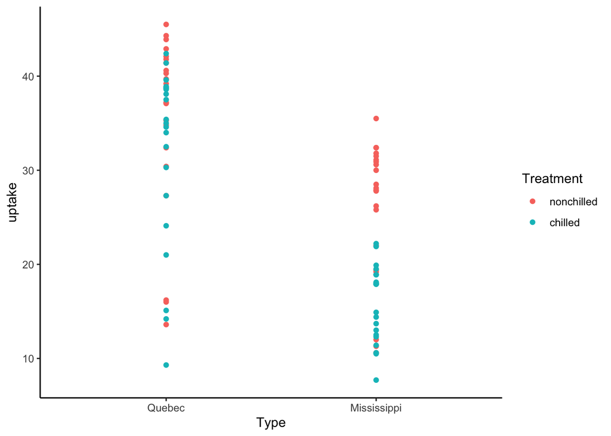

```r
ggplot(CO2, aes(y = uptake, x = Type)) +geom_point(aes(color = Treatment)) +
  theme_classic()
```

## Task 7

### 1. Install the Tidybiology package, which includes the data ‘chromosome’ and ‘proteins’

```r
#devtools::install_github("hirscheylab/tidybiology")
library(tidybiology)
```

##### a. Extract summary statistics (mean, median and maximum) for the following variables from the ‘chromosome’ data: variations, protein coding genes, and miRNAs. Utilize the tidyverse functions to make this as simply as possible.

```r
summary(chromosome)
```

```
##        id       length_mm       basepairs           variations
##  1      : 1   Min.   :16.00   Min.   : 46709983   Min.   :  211643
##  2      : 1   1st Qu.:27.75   1st Qu.: 82536402   1st Qu.: 4395298
##  3      : 1   Median :45.50   Median :133536366   Median : 6172346
##  4      : 1   Mean   :43.83   Mean   :128677910   Mean   : 6484572
##  5      : 1   3rd Qu.:55.00   3rd Qu.:162210974   3rd Qu.: 8742592
##  6      : 1   Max.   :85.00   Max.   :248956422   Max.   :12945965
##  (Other):18
##  protein_codinggenes  pseudo_genes    totallongnc_rna  totalsmallnc_rna
##  Min.   :  71.0      Min.   : 185.0   Min.   :  71.0   Min.   : 30.0
##  1st Qu.: 595.8      1st Qu.: 445.8   1st Qu.: 439.0   1st Qu.:167.0
##  Median : 836.0      Median : 590.5   Median : 633.5   Median :220.5
##  Mean   : 850.0      Mean   : 608.3   Mean   : 613.6   Mean   :208.9
##  3rd Qu.:1055.5      3rd Qu.: 772.5   3rd Qu.: 751.0   3rd Qu.:236.0
##  Max.   :2058.0      Max.   :1220.0   Max.   :1200.0   Max.   :496.0
##
##      mi_rna           r_rna           sn_rna          sno_rna
##  Min.   : 15.00   Min.   : 5.00   Min.   : 17.00   Min.   :  3.00
##  1st Qu.: 55.75   1st Qu.:13.00   1st Qu.: 49.75   1st Qu.: 36.75
##  Median : 75.00   Median :23.00   Median : 77.00   Median : 59.50
##  Mean   : 73.17   Mean   :22.08   Mean   : 81.00   Mean   : 63.38
##  3rd Qu.: 92.00   3rd Qu.:27.25   3rd Qu.:106.00   3rd Qu.: 76.00
##  Max.   :134.00   Max.   :66.00   Max.   :221.00   Max.   :145.00
##
##    miscnc_rna     centromereposition_mbp
##  Min.   :  8.00   Min.   : 12.50
##  1st Qu.: 66.50   1st Qu.: 18.73
##  Median : 94.50   Median : 38.40
##  Mean   : 92.21   Mean   : 43.36
##  3rd Qu.:107.50   3rd Qu.: 55.25
##  Max.   :192.00   Max.   :125.00
##
```

##### b. How does the chromosome size distribute? Plot a graph that helps to visualize this by using ggplot2 package functions.

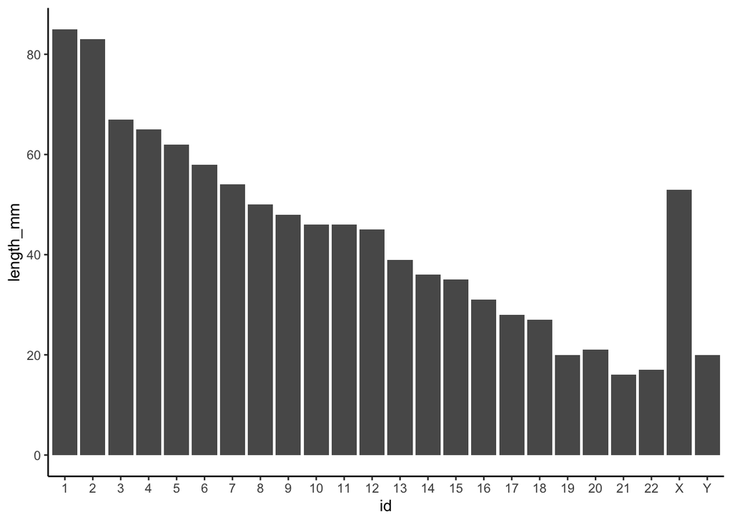

```r
ggplot(chromosome, aes(y = length_mm, x = id)) +geom_col() +theme_classic()
```

##### c. Does the number of protein coding genes or miRNAs correlate with the length of the chromosome? Make two separate plots to visualize these relationships.

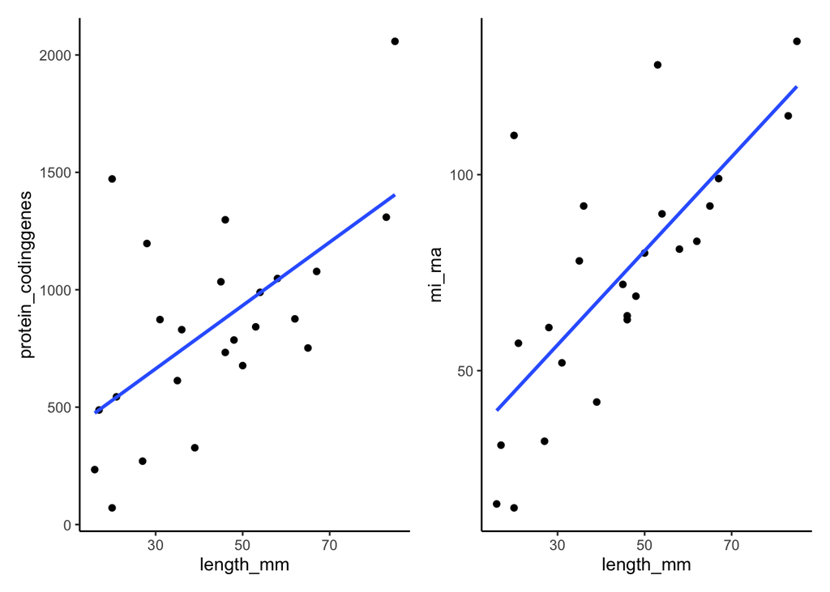

```r
library(patchwork)
options(repr.plot.width = 8, repr.plot.height = 4, repr.plot.res = 150)
p1= ggplot(chromosome, aes(x = length_mm, y = protein_codinggenes)) + geom_point() + geom_smooth(method=lm, se=FALSE) +theme_classic()
p2= ggplot(chromosome, aes(x = length_mm, y = mi_rna)) + geom_point() + geom_smooth(method=lm, se=FALSE) +theme_classic()
p1+p2+plot_layout(ncol=2)
```

##### d. Calculate the same summary statistics for the ‘proteins’ data variables length and mass. Create a meaningful visualization of the relationship between these two variables by utilizing the ggplot2 package functions. Play with the colors, theme- and other visualization parameters to create a plot that pleases you.

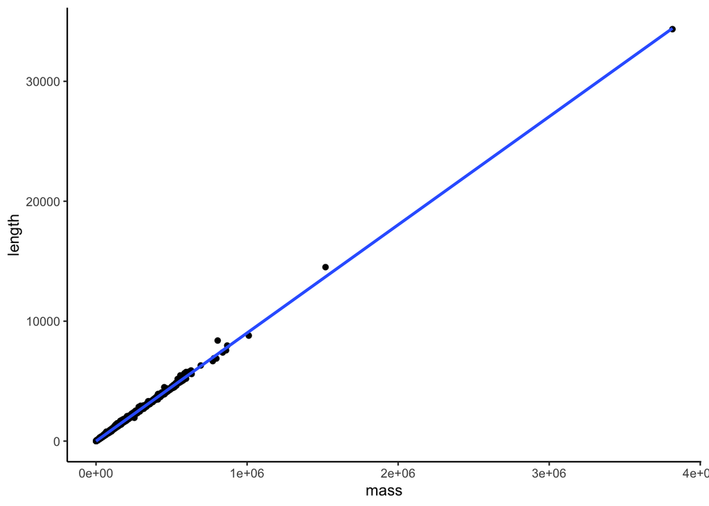

```r
ggplot(proteins, aes(x = mass, y = length)) + geom_point() + geom_smooth(method=lm, se=FALSE) +theme_classic()
```